# Causal Mediation Examples

Simon Brewer

06 June, 2023

## Libraries and whatnot

```r
library(tidyverse)
# library(broom)
library(patchwork)
library(scales)
library(dagitty)
library(ggdag)
library(latex2exp)  # Easily convert LaTeX into arcane plotmath expressions
library(ggtext)     # Use markdown in ggplot labels

# Create a cleaner serifed theme to use throughout
theme_do_calc <- function() {
  theme_dag(base_family = "Times New Roman") +
    theme(plot.title = element_text(size = rel(1.5)),
          plot.subtitle = element_markdown())
}

# Make all geom_dag_text() layers use these settings automatically
update_geom_defaults(ggdag:::GeomDagText, list(family = "Times New Roman",
                                               fontface = "bold",
                                               color = "black"))
```

## Examples

In all the examples that follow, we are trying to estimate a causal relationship between `x` and `y`. I think this is $P(Y| \mbox{do}(X=x))$ **NEED TO CHECK THIS**

## Chains

This represents a sequential path from intervention to outcome via a confounder (`x` → `z` → `y`). Can bias causal link between `x` and `y` *if `z` is included*.

### Simple chain (no direct link)

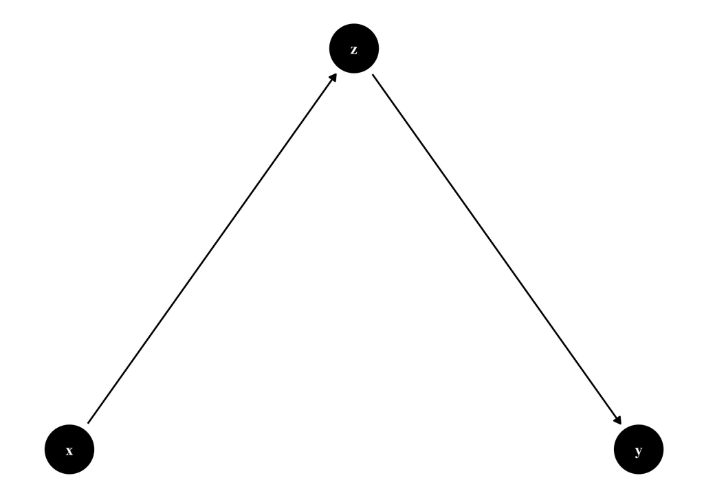

```r
chain_dag <- dagify(z ~ x,
                    y ~ z,
                    coords = list(x = c(x = 1, y = 3, z = 2),
                                  y = c(x = 1, y = 1, z = 2)),
                    exposure = "x",
                    outcome = "y")

ggdag(chain_dag) +
  theme_dag()
```

Independence: `x` and `y` are independent (conditioned on `z`)

```r
impliedConditionalIndependencies(chain_dag)
```

```
## x _||_ y | z
```

Adjustment set: shows what adjustment is necessary to obtain the causal link between input and outcome

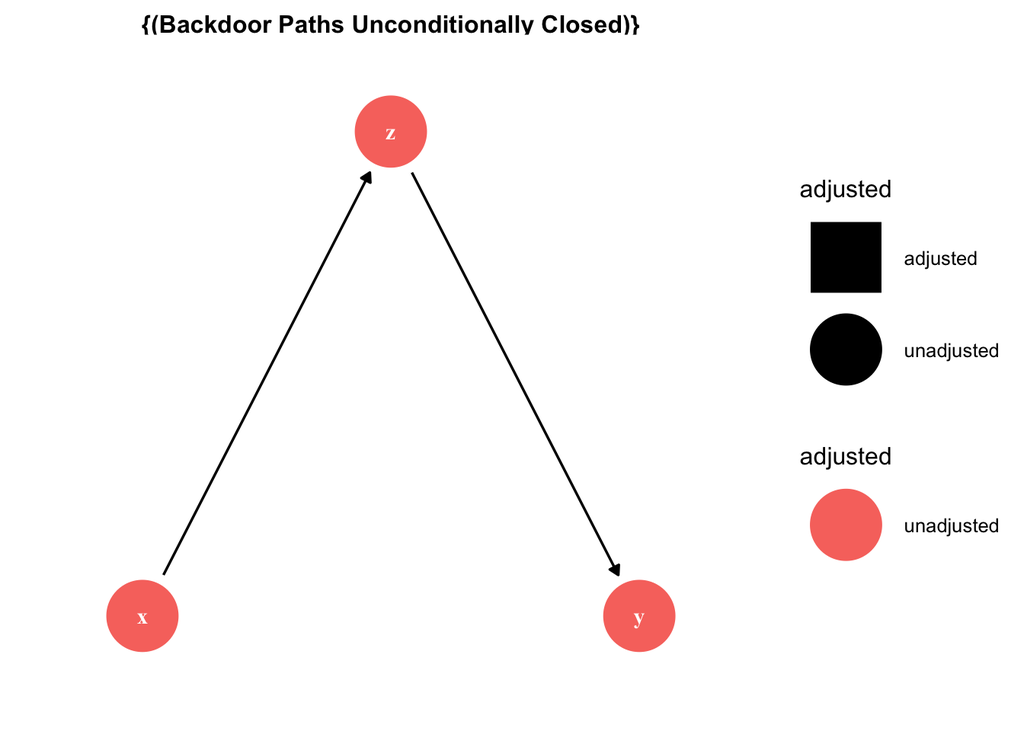

```r
ggdag_adjustment_set(chain_dag) +
  theme_dag()
```

Simulated data - Equations

- `x`: $N(5, 1)$
- `x ~ z`: $\beta_1 = 4$
- `y ~ z`: $\beta_2 = 2$

```r
n <- 1000
x <- rnorm(n, 5, 1)
z <- x * 4 + rnorm(n, 0, 2)
y <- z * 2 + rnorm(n, 0, 2)
df <- data.frame(x, y, z)
```

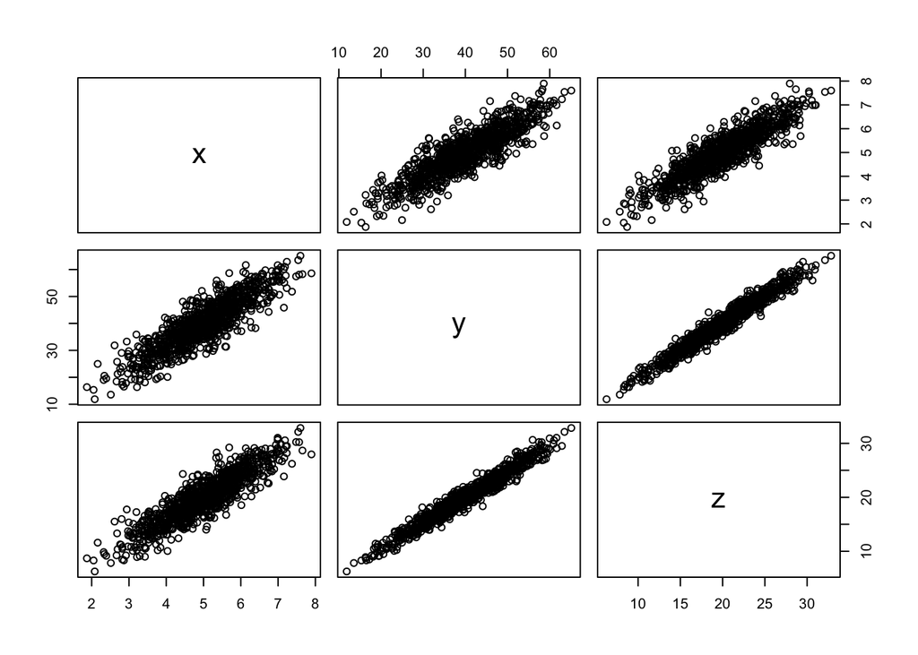

```r
pairs(df)
```

Model of `y ~ x`. If we ignore the confounder, we get the total effect of `x` on `y`. This includes any direct effect (`x` → `y`) and and indirect effect (`x` → `z` → `y`). In a simple linear case, the total effect should be the linear combination of these two equations. Here we have:

- $z = x \times 4$
- $y = z \times 2$
- No direct effect

So the total direct effect via `z` is $2 \times 4 = 8$. As there is no direct effect, this is the causal effect of `x` on `y`:

```r
fit <- lm(y ~ x, df)
summary(fit)
```

```
##
## Call:
## lm(formula = y ~ x, data = df)
##
## Residuals:
##      Min       1Q   Median       3Q      Max
## -13.5240  -3.0180   0.0478   3.0820  13.1542
##
## Coefficients:
##             Estimate Std. Error t value Pr(>|t|)
## (Intercept)  -0.4856     0.7279  -0.667    0.505
## x             8.0857     0.1430  56.529   <2e-16 ***
## ---
## Signif. codes:  0 '***' 0.001 '**' 0.01 '*' 0.05 '.' 0.1 ' ' 1
##
## Residual standard error: 4.491 on 998 degrees of freedom
## Multiple R-squared:  0.762,  Adjusted R-squared:  0.7618
## F-statistic:  3196 on 1 and 998 DF,  p-value: < 2.2e-16
```

Model controlling for `z`. This removes the path between `x` and `y` and removes the apparent relationship. Now we only see the relationship between `z` and `y`. This is *overcontrol*: we’ve biased the estimate of the causal link between `x` and `y` by controlling for the intermediate variable

```r
fit <- lm(y ~ x + z, df)
summary(fit)
```

```
##
## Call:
## lm(formula = y ~ x + z, data = df)
##
## Residuals:
##     Min      1Q  Median      3Q     Max
## -6.5543 -1.3356  0.0109  1.3548  7.3978
##
## Coefficients:
##               Estimate Std. Error t value Pr(>|t|)
## (Intercept) -0.3191123  0.3207317  -0.995    0.320
## x            0.0002673  0.1405256   0.002    0.998
## z            2.0191560  0.0313663  64.373   <2e-16 ***
## ---
## Signif. codes:  0 '***' 0.001 '**' 0.01 '*' 0.05 '.' 0.1 ' ' 1
##
## Residual standard error: 1.979 on 997 degrees of freedom
## Multiple R-squared:  0.9538, Adjusted R-squared:  0.9538
## F-statistic: 1.03e+04 on 2 and 997 DF,  p-value: < 2.2e-16
```

### Simple chain (direct link)

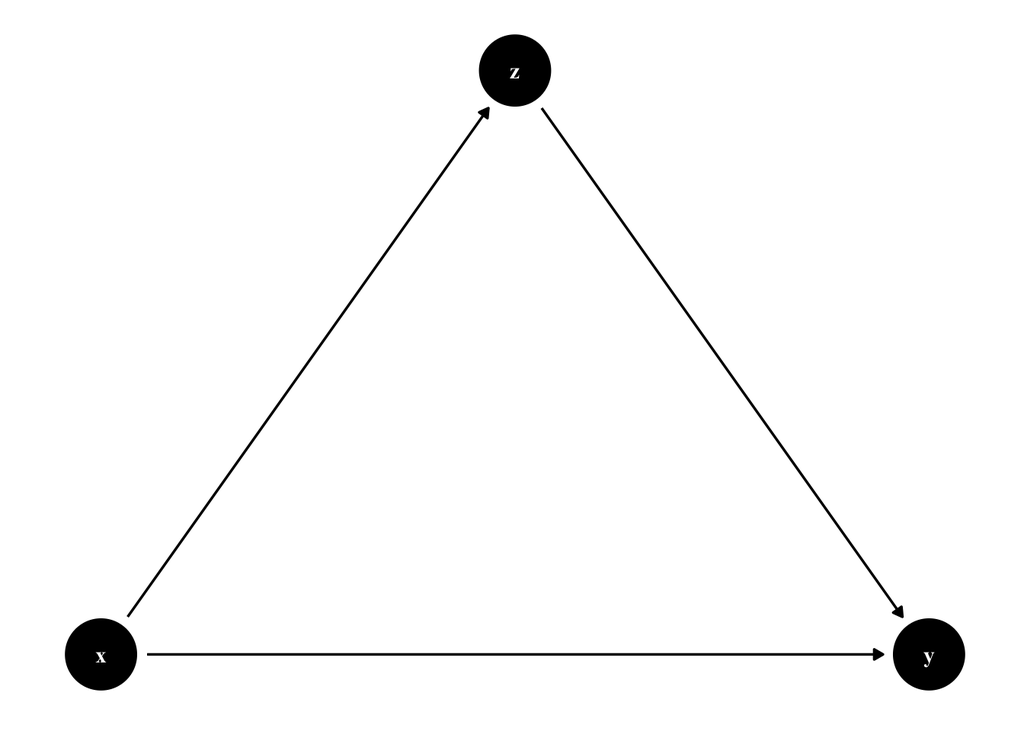

```r
chain_dag <- dagify(z ~ x,
                    y ~ x + z,
                    coords = list(x = c(x = 1, y = 3, z = 2),
                                  y = c(x = 1, y = 1, z = 2)),
                    exposure = "x",
                    outcome = "y")

ggdag(chain_dag) +
  theme_dag()
```

Independence: `x` and `y` are *not* independent (even conditioned on `z`)

```r
impliedConditionalIndependencies(chain_dag)
```

Adjustment set: shows what adjustment is necessary to obtain the causal link between input and outcome

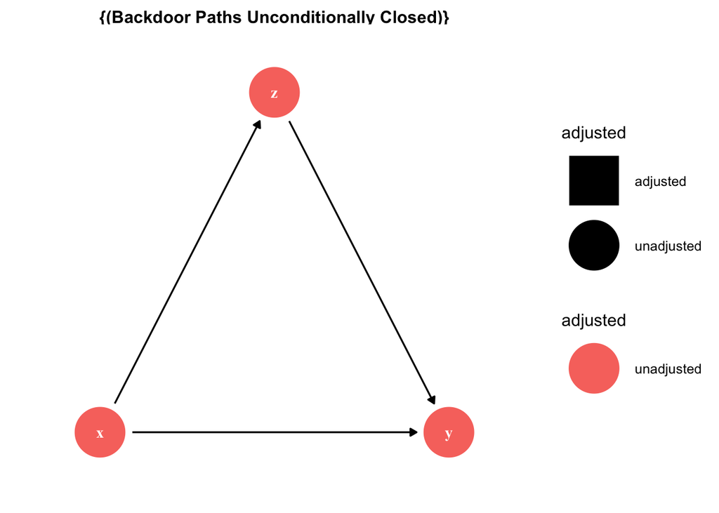

```r
ggdag_adjustment_set(chain_dag) +
  theme_dag()
```

Simulated data - Equations

```r
n <- 1000
x <- rnorm(n, 10, 5)
z <- x * 5 + rnorm(n, 0, 2)
y <- x * -1.5 + z * 2 + rnorm(n, 0, 2)
df <- data.frame(x, y, z)
```

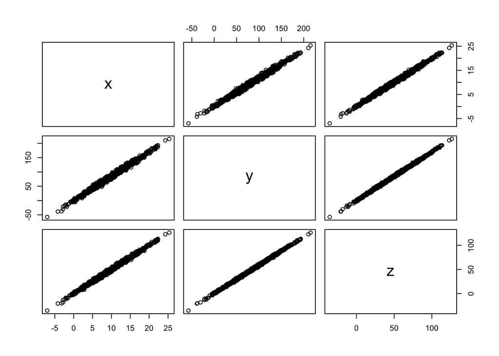

```r
pairs(df)
```

Model of `y ~ x`. Ignoring the confounder gives us the total causal effect. Here, we have three effects at play:

- $z = x \times 5$
- $y = z \times 2 + x \times -1.5$

Now the indirect effect via `z` is $5 \times 2 = 10$, and the direct effect is $-1.5$, giving us a total effect of $10 - 1.5 = 8.5$. Let’s see what the model says:

```r
fit <- lm(y ~ x, df)
summary(fit)
```

```
##
## Call:
## lm(formula = y ~ x, data = df)
##
## Residuals:
##      Min       1Q   Median       3Q      Max
## -15.2030  -2.9979   0.0844   3.0120  12.1991
##
## Coefficients:
##             Estimate Std. Error t value Pr(>|t|)
## (Intercept) -0.34263    0.31139    -1.1    0.271
## x            8.54880    0.02852   299.7   <2e-16 ***
## ---
## Signif. codes:  0 '***' 0.001 '**' 0.01 '*' 0.05 '.' 0.1 ' ' 1
##
## Residual standard error: 4.414 on 998 degrees of freedom
## Multiple R-squared:  0.989,  Adjusted R-squared:  0.989
## F-statistic: 8.984e+04 on 1 and 998 DF,  p-value: < 2.2e-16
```

Model controlling for `z`. By controlling for `z`, we no longer can observe the total effect of `x` (overcontrol). However, this does isolate the 2 single paths `x` → `y` and `z` → `y` correctly.

```r
fit <- lm(y ~ x + z, df)
summary(fit)
```

```
##
## Call:
## lm(formula = y ~ x + z, data = df)
##
## Residuals:
##     Min      1Q  Median      3Q     Max
## -6.2021 -1.3593  0.0702  1.4369  5.6507
##
## Coefficients:
##              Estimate Std. Error t value Pr(>|t|)
## (Intercept)  0.005361   0.139614   0.038    0.969
## x           -1.336196   0.157298  -8.495   <2e-16 ***
## z            1.968334   0.031218  63.051   <2e-16 ***
## ---
## Signif. codes:  0 '***' 0.001 '**' 0.01 '*' 0.05 '.' 0.1 ' ' 1
##
## Residual standard error: 1.977 on 997 degrees of freedom
## Multiple R-squared:  0.9978, Adjusted R-squared:  0.9978
## F-statistic: 2.258e+05 on 2 and 997 DF,  p-value: < 2.2e-16
```